# Оценка рынка недвижимости Санкт-Петербурга и Ленинградской области

**Цель исследования** - Нахождение зависимостей между различными параметрами жилья, такими как площадь квартиры, удленность от центра города, наличие балкона и другие.

**Ход исследования**

Данные о поведении пользователей получены из файла с расширением .csv. К данным приложена документация, однако могут встречаться пропуски или значения, искажающие данные. Поэтому перед проверкой гипотез требуется провести обзор данных и их обработку.

Далее необходимо провести анализ следующих параметров:

- Оценить распределение значений основных параметров
- Изучить время, за которое обычно продаются квартиры
- Оценить влияние различных параметров на стоимость недвижимости
- Определить среднюю стоимость за м2 для различных населенных пунктов
- Выяснить зависимость стоимости недвижимости от расстояния до центра

## Обзор данных

В исследовании используются средства библиотеки `pandas`. Данные получены в виде файла с расширением .csv

```python
import pandas as pd
import numpy as np
import matplotlib.pyplot as plt
import warnings
warnings.filterwarnings('ignore')
```

```python
try:
    df = pd.read_csv('/Datasets/real_estate_data.csv', sep='\t')
except:
    df = pd.read_csv('https://code.s3.yandex.net/datasets/real_estate_data.csv', sep='\t')
```

Для общего представления о полученных данных осуществляется вывод первых 5-ти строк таблицы, а также используется метод `info`.

```python
df.head()
```

|  | total_images | last_price | total_area | first_day_exposition | rooms | ceiling_height | floors_total | living_area | floor | is_apartment | ... | kitchen_area | balcony | locality_name | airports_nearest | cityCenters_nearest | parks_around3000 | parks_nearest | ponds_around3000 | ponds_nearest | days_exposition |
| --- | --- | --- | --- | --- | --- | --- | --- | --- | --- | --- | --- | --- | --- | --- | --- | --- | --- | --- | --- | --- | --- |
| 0 | 20 | 13000000.0 | 108.0 | 2019-03-07T00:00:00 | 3 | 2.70 | 16.0 | 51.0 | 8 | NaN | ... | 25.0 | NaN | Санкт-Петербург | 18863.0 | 16028.0 | 1.0 | 482.0 | 2.0 | 755.0 | NaN |
| 1 | 7 | 3350000.0 | 40.4 | 2018-12-04T00:00:00 | 1 | NaN | 11.0 | 18.6 | 1 | NaN | ... | 11.0 | 2.0 | посёлок Шушары | 12817.0 | 18603.0 | 0.0 | NaN | 0.0 | NaN | 81.0 |
| 2 | 10 | 5196000.0 | 56.0 | 2015-08-20T00:00:00 | 2 | NaN | 5.0 | 34.3 | 4 | NaN | ... | 8.3 | 0.0 | Санкт-Петербург | 21741.0 | 13933.0 | 1.0 | 90.0 | 2.0 | 574.0 | 558.0 |
| 3 | 0 | 64900000.0 | 159.0 | 2015-07-24T00:00:00 | 3 | NaN | 14.0 | NaN | 9 | NaN | ... | NaN | 0.0 | Санкт-Петербург | 28098.0 | 6800.0 | 2.0 | 84.0 | 3.0 | 234.0 | 424.0 |
| 4 | 2 | 10000000.0 | 100.0 | 2018-06-19T00:00:00 | 2 | 3.03 | 14.0 | 32.0 | 13 | NaN | ... | 41.0 | NaN | Санкт-Петербург | 31856.0 | 8098.0 | 2.0 | 112.0 | 1.0 | 48.0 | 121.0 |

5 rows × 22 columns

**Наименования столбцов**

`airports_nearest` — расстояние до ближайшего аэропорта в метрах (м)  
`balcony` — число балконов  
`ceiling_height` — высота потолков (м)  
`cityCenters_nearest` — расстояние до центра города (м)  
`days_exposition` — сколько дней было размещено объявление (от публикации до снятия)  
`first_day_exposition` — дата публикации  
`floor` — этаж  
`floors_total` — всего этажей в доме  
`is_apartment` — апартаменты (булев тип)  
`kitchen_area` — площадь кухни в квадратных метрах (м²)  
`last_price` — цена на момент снятия с публикации  
`living_area` — жилая площадь в квадратных метрах (м²)  
`locality_name` — название населённого пункта  
`open_plan` — свободная планировка (булев тип)  
`parks_around3000` — число парков в радиусе 3 км  
`parks_nearest` — расстояние до ближайшего парка (м)  
`ponds_around3000` — число водоёмов в радиусе 3 км  
`ponds_nearest` — расстояние до ближайшего водоёма (м)  
`rooms` — число комнат  
`studio` — квартира-студия (булев тип)  
`total_area` — общая площадь квартиры в квадратных метрах (м²)  
`total_images` — число фотографий квартиры в объявлении

[figure not shown]

```python
df.hist(figsize=(15, 20));
```

По области значений гистограмм заметно, что среди значений многих столбцов имеются "выбросы" - значения, сильно отличающиеся от большинства.

```python
df.info()
```

```
<class 'pandas.core.frame.DataFrame'>
RangeIndex: 23699 entries, 0 to 23698
Data columns (total 22 columns):
 #   Column                Non-Null Count  Dtype
---  ------                --------------  -----
 0   total_images          23699 non-null  int64
 1   last_price            23699 non-null  float64
 2   total_area            23699 non-null  float64
 3   first_day_exposition  23699 non-null  object
 4   rooms                 23699 non-null  int64
 5   ceiling_height        14504 non-null  float64
 6   floors_total          23613 non-null  float64
 7   living_area           21796 non-null  float64
 8   floor                 23699 non-null  int64
 9   is_apartment          2775 non-null   object
 10  studio                23699 non-null  bool
 11  open_plan             23699 non-null  bool
 12  kitchen_area          21421 non-null  float64
 13  balcony               12180 non-null  float64
 14  locality_name         23650 non-null  object
 15  airports_nearest      18157 non-null  float64
 16  cityCenters_nearest   18180 non-null  float64
 17  parks_around3000      18181 non-null  float64
 18  parks_nearest         8079 non-null   float64
 19  ponds_around3000      18181 non-null  float64
 20  ponds_nearest         9110 non-null   float64
 21  days_exposition       20518 non-null  float64
dtypes: bool(2), float64(14), int64(3), object(3)
memory usage: 3.7+ MB
```

```python
# check
# пропущенные значения бары

def pass_value_barh(df):
    try:
        (
            (df.isna().mean()*100)
            .to_frame()
            .rename(columns = {0:'space'})
            .query('space > 0')
            .sort_values(by = 'space', ascending = True)
            .plot(kind= 'barh', figsize=(19,6), rot = -5, legend = False, fontsize = 16)
            .set_title('Пример' + "\n", fontsize = 22, color = 'SteelBlue')
        );
    except:
        print('пропусков не осталось :) ')
```

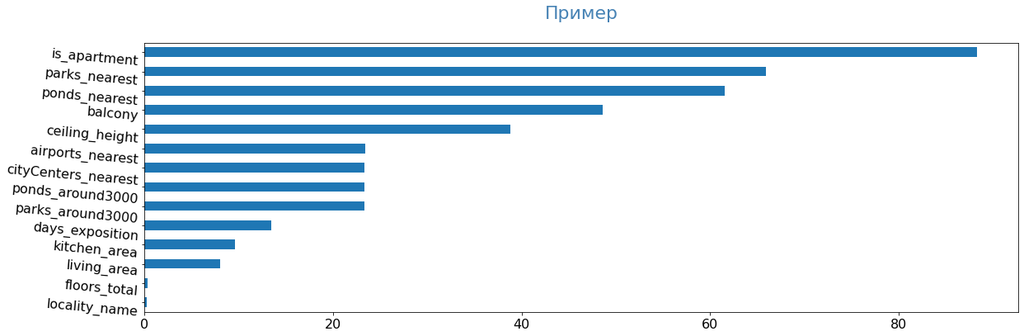

```python
pass_value_barh(df)
```

Наблюдается значительное количество пропусков.  
Для некоторых столбцов доля отсутствующих значений составляет более 50%.  
Необходимо оценить распределение данных и по возможности заполнить пропуски.

## Предобработка данных

### Обработка пропущенных значений

В данных наблюдаются множественные пропуски, потребуется их изучение и заполнение релевантными значениями

**Высота потолков**

Поскольку высота потолков зависит от типа здания, а также от района и населенного пункта, заполнение медианным значением недопустимо. В связи с этим пропуски заполняются значением `0` и не будут учитываться в исследовании.

```python
df['ceiling_height'].fillna(0, inplace = True)
```

**Этажность здания**

```python
df['floors_total'].unique()
```

```
array([16., 11.,  5., 14., 12., 26., 24., 27.,  9.,  6., 17., 25.,  3.,
       23., 19., 18.,  4., 22.,  8.,  2., 10.,  7., 13., 15., nan, 20.,
       28., 36., 21., 35., 34., 60.,  1., 29., 33., 52., 37.])
```

Выбросов не обнаружено, пропуски можно заполнить медианным значением и привести к целочисленным значениям.

```python
df['floors_total'].median()
```

```
9.0
```

Следует учесть, что поскольку медианное значение общей этажности равно 9, для некоторых объектов значение общей этажности может оказаться меньше этажа, на котором расположена квартира.

Предположить реальное значение этажности этих зданий невозможно, поэтому оставшиеся данные заменяются на `0` и не будут использованы в исследовании.

```python
df[df['floors_total'] >= df['floors_total'].median()]['floors_total'].fillna(df['floors_total'].median(), inplace = True)
df['floors_total'].fillna(0, inplace = True)

df['floors_total'] = df['floors_total'].astype(int)
```

```python
df[df['floors_total'] < df['floor']]['floors_total']
```

```
186      0
237      0
457      0
671      0
1757     0
        ..
22542    0
22656    0
22808    0
23590    0
23658    0
Name: floors_total, Length: 86, dtype: int32
```

```python
print(f"Всего значений, где общая этажность оказалась ниже этажности квартиры - {len(df[df['floors_total'] < df['floor']]['floors_total'])}")
```

```
Всего значений, где общая этажность оказалась ниже этажности квартиры - 86
```

**Жилая площадь и площадь кухни**

Для заполнения пропусков в этих столбцах целесообразно оценить, какую долю от общей площади занимает жилая площадь и кухня соответственно.

Таким образом, можно предсказать эти значения там, где они пропущены.

```python
def living_area_fill (row):
    if np.isnan(row['living_area']):
        return row['total_area'] * (df['living_area']/df['total_area']).mean()
    return row['living_area']

def kitchen_area_fill (row):
    if np.isnan(row['kitchen_area']):
        return row['total_area'] * (df['kitchen_area']/df['total_area']).mean()
    return row['kitchen_area']
```

```python
df['living_area'] = df.apply(living_area_fill, axis =1)
df['kitchen_area'] = df.apply(kitchen_area_fill, axis =1)
```

**Количество балконов**  
**Наличие парков и прудов поблизости**

В случае, если количество балконов, а также количество прудов и парков в радиусе 3х километров не указано, предположим, что их нет. Отсутствующие значения заменяются на `0`

```python
df['balcony'].fillna(0, inplace = True)
df['parks_around3000'].fillna(0, inplace = True)
df['ponds_around3000'].fillna(0, inplace = True)

df['balcony'] = df['balcony'].astype(int)
df['parks_around3000'] = df['parks_around3000'].astype(int)
df['ponds_around3000'] = df['ponds_around3000'].astype(int)
```

**Длительность размещения объявления**

Срок размещения объявления предсказать невозможно. Пропущенные значения заменяются на `0` т.к. точное значение предположить невозможно. В дальнейшем эти значения не будут использованы в исследовании.

```python
df['days_exposition'].fillna(0, inplace = True)
df['days_exposition'] = df['days_exposition'].astype(int)
```

**Населенный пункт**

Отсутствующие значения в столбце `Населенный пункт` заменяются значением `Неизвестно`

```python
df.groupby('locality_name')['last_price'].count().sort_values(ascending=False)
```

```
locality_name
Санкт-Петербург       15721
посёлок Мурино          522
посёлок Шушары          440
Всеволожск              398
Пушкин                  369
                      ...
поселок Каложицы          1
поселок Кирпичное         1
поселок Коммунары         1
поселок Коробицыно        1
село Шум                  1
Name: last_price, Length: 364, dtype: int64
```

```python
df['locality_name'].fillna('Неизвестно', inplace = True)
```

**Апартаменты**

Если не указано, используется ли недвижимость как апартаменты, предполагается, что нет. Пропущенные значения заменяются на `False`

```python
df['is_apartment'].fillna(False, inplace = True)
df['is_apartment'] = df['is_apartment'].astype(bool)
```

**Инфраструктура**

Если не указано, на каком расстоянии находится аэропорт, а также парки и пруды, предполагается что аэропорта поблизости нет. Пропущенные значения заменяются на `0` т.к. точное значение предположить невозможно. В дальнейшем эти значения не будут использованы в исследовании.

```python
infrastructure_list = ['airports_nearest', 'cityCenters_nearest', 'parks_nearest', 'ponds_nearest']

for infrastructure in infrastructure_list:
    df[infrastructure].fillna(0, inplace = True)
    df[infrastructure] = df[infrastructure].astype(int)
```

**Проверка заполнения пропусков**

```python
df.info()
```

```
<class 'pandas.core.frame.DataFrame'>
RangeIndex: 23699 entries, 0 to 23698
Data columns (total 22 columns):
 #   Column                Non-Null Count  Dtype
---  ------                --------------  -----
 0   total_images          23699 non-null  int64
 1   last_price            23699 non-null  float64
 2   total_area            23699 non-null  float64
 3   first_day_exposition  23699 non-null  object
 4   rooms                 23699 non-null  int64
 5   ceiling_height        23699 non-null  float64
 6   floors_total          23699 non-null  int32
 7   living_area           23699 non-null  float64
 8   floor                 23699 non-null  int64
 9   is_apartment          23699 non-null  bool
 10  studio                23699 non-null  bool
 11  open_plan             23699 non-null  bool
 12  kitchen_area          23699 non-null  float64
 13  balcony               23699 non-null  int32
 14  locality_name         23699 non-null  object
 15  airports_nearest      23699 non-null  int32
 16  cityCenters_nearest   23699 non-null  int32
 17  parks_around3000      23699 non-null  int32
 18  parks_nearest         23699 non-null  int32
 19  ponds_around3000      23699 non-null  int32
 20  ponds_nearest         23699 non-null  int32
 21  days_exposition       23699 non-null  int32
dtypes: bool(3), float64(5), int32(9), int64(3), object(2)
memory usage: 2.7+ MB
```

Все пропущенные значения заполнены.

### Обработка некорректных значений

**Высота потолков**

```python
df['ceiling_height'].sort_values().unique()
```

```
array([  0.  ,   1.  ,   1.2 ,   1.75,   2.  ,   2.2 ,   2.25,   2.3 ,
         2.34,   2.4 ,   2.45,   2.46,   2.47,   2.48,   2.49,   2.5 ,
         2.51,   2.52,   2.53,   2.54,   2.55,   2.56,   2.57,   2.58,
         2.59,   2.6 ,   2.61,   2.62,   2.63,   2.64,   2.65,   2.66,
         2.67,   2.68,   2.69,   2.7 ,   2.71,   2.72,   2.73,   2.74,
         2.75,   2.76,   2.77,   2.78,   2.79,   2.8 ,   2.81,   2.82,
         2.83,   2.84,   2.85,   2.86,   2.87,   2.88,   2.89,   2.9 ,
         2.91,   2.92,   2.93,   2.94,   2.95,   2.96,   2.97,   2.98,
         2.99,   3.  ,   3.01,   3.02,   3.03,   3.04,   3.05,   3.06,
         3.07,   3.08,   3.09,   3.1 ,   3.11,   3.12,   3.13,   3.14,
         3.15,   3.16,   3.17,   3.18,   3.2 ,   3.21,   3.22,   3.23,
         3.24,   3.25,   3.26,   3.27,   3.28,   3.29,   3.3 ,   3.31,
         3.32,   3.33,   3.34,   3.35,   3.36,   3.37,   3.38,   3.39,
         3.4 ,   3.42,   3.43,   3.44,   3.45,   3.46,   3.47,   3.48,
         3.49,   3.5 ,   3.51,   3.52,   3.53,   3.54,   3.55,   3.56,
         3.57,   3.58,   3.59,   3.6 ,   3.62,   3.63,   3.65,   3.66,
         3.67,   3.68,   3.69,   3.7 ,   3.75,   3.76,   3.78,   3.8 ,
         3.82,   3.83,   3.84,   3.85,   3.86,   3.87,   3.88,   3.9 ,
         3.93,   3.95,   3.98,   4.  ,   4.06,   4.1 ,   4.14,   4.15,
         4.19,   4.2 ,   4.25,   4.3 ,   4.37,   4.4 ,   4.45,   4.5 ,
         4.65,   4.7 ,   4.8 ,   4.9 ,   5.  ,   5.2 ,   5.3 ,   5.5 ,
         5.6 ,   5.8 ,   6.  ,   8.  ,   8.3 ,  10.3 ,  14.  ,  20.  ,
        22.6 ,  24.  ,  25.  ,  26.  ,  27.  ,  27.5 ,  32.  , 100.  ])
```

Наблюдаются аномально высокие значения, такие как 27.0, 32.0. Вероятнее всего, реальные значения - 2.7, 3.2 соответственно.  
Все значения больше 20м заменяются на порядок меньшими.

```python
for index in range(len(df['ceiling_height'])):
    if df.loc[index, 'ceiling_height'] > 20:
        df.loc[index, 'ceiling_height'] = df.loc[index, 'ceiling_height']/10
```

```python
df['ceiling_height'].sort_values().unique()
```

```
array([ 0.  ,  1.  ,  1.2 ,  1.75,  2.  ,  2.2 ,  2.25,  2.26,  2.3 ,
        2.34,  2.4 ,  2.45,  2.46,  2.47,  2.48,  2.49,  2.5 ,  2.51,
        2.52,  2.53,  2.54,  2.55,  2.56,  2.57,  2.58,  2.59,  2.6 ,
        2.61,  2.62,  2.63,  2.64,  2.65,  2.66,  2.67,  2.68,  2.69,
        2.7 ,  2.71,  2.72,  2.73,  2.74,  2.75,  2.76,  2.77,  2.78,
        2.79,  2.8 ,  2.81,  2.82,  2.83,  2.84,  2.85,  2.86,  2.87,
        2.88,  2.89,  2.9 ,  2.91,  2.92,  2.93,  2.94,  2.95,  2.96,
        2.97,  2.98,  2.99,  3.  ,  3.01,  3.02,  3.03,  3.04,  3.05,
        3.06,  3.07,  3.08,  3.09,  3.1 ,  3.11,  3.12,  3.13,  3.14,
        3.15,  3.16,  3.17,  3.18,  3.2 ,  3.21,  3.22,  3.23,  3.24,
        3.25,  3.26,  3.27,  3.28,  3.29,  3.3 ,  3.31,  3.32,  3.33,
        3.34,  3.35,  3.36,  3.37,  3.38,  3.39,  3.4 ,  3.42,  3.43,
        3.44,  3.45,  3.46,  3.47,  3.48,  3.49,  3.5 ,  3.51,  3.52,
        3.53,  3.54,  3.55,  3.56,  3.57,  3.58,  3.59,  3.6 ,  3.62,
        3.63,  3.65,  3.66,  3.67,  3.68,  3.69,  3.7 ,  3.75,  3.76,
        3.78,  3.8 ,  3.82,  3.83,  3.84,  3.85,  3.86,  3.87,  3.88,
        3.9 ,  3.93,  3.95,  3.98,  4.  ,  4.06,  4.1 ,  4.14,  4.15,
        4.19,  4.2 ,  4.25,  4.3 ,  4.37,  4.4 ,  4.45,  4.5 ,  4.65,
        4.7 ,  4.8 ,  4.9 ,  5.  ,  5.2 ,  5.3 ,  5.5 ,  5.6 ,  5.8 ,
        6.  ,  8.  ,  8.3 , 10.  , 10.3 , 14.  , 20.  ])
```

**Наименования населенных пунктов**

Наименования населенных пунктов могут быть записаны по-разному, поэтому необходимо привести их к единому виду.

```python
df['locality_name'].sort_values().unique()
```

```
array(['Бокситогорск', 'Волосово', 'Волхов', 'Всеволожск', 'Выборг',
       'Высоцк', 'Гатчина', 'Зеленогорск', 'Ивангород', 'Каменногорск',
       'Кингисепп', 'Кириши', 'Кировск', 'Колпино', 'Коммунар',
       'Красное Село', 'Кронштадт', 'Кудрово', 'Лодейное Поле',
       'Ломоносов', 'Луга', 'Любань', 'Мурино', 'Неизвестно',
       'Никольское', 'Новая Ладога', 'Отрадное', 'Павловск', 'Петергоф',
       'Пикалёво', 'Подпорожье', 'Приморск', 'Приозерск', 'Пушкин',
       'Санкт-Петербург', 'Светогорск', 'Сертолово', 'Сестрорецк',
       'Сланцы', 'Сосновый Бор', 'Сясьстрой', 'Тихвин', 'Тосно',
       'Шлиссельбург', 'городской поселок Большая Ижора',
       'городской поселок Янино-1', 'городской посёлок Будогощь',
       'городской посёлок Виллози', 'городской посёлок Лесогорский',
       'городской посёлок Мга', 'городской посёлок Назия',
       'городской посёлок Новоселье', 'городской посёлок Павлово',
       'городской посёлок Рощино', 'городской посёлок Свирьстрой',
       'городской посёлок Советский', 'городской посёлок Фёдоровское',
       'городской посёлок Янино-1', 'деревня Агалатово', 'деревня Аро',
       'деревня Батово', 'деревня Бегуницы', 'деревня Белогорка',
       'деревня Большая Вруда', 'деревня Большая Пустомержа',
       'деревня Большие Колпаны', 'деревня Большое Рейзино',
       'деревня Большой Сабск', 'деревня Бор', 'деревня Борисова Грива',
       'деревня Ваганово', 'деревня Вартемяги', 'деревня Вахнова Кара',
       'деревня Выскатка', 'деревня Гарболово', 'деревня Глинка',
       'деревня Горбунки', 'деревня Гостилицы', 'деревня Заклинье',
       'деревня Заневка', 'деревня Зимитицы', 'деревня Извара',
       'деревня Иссад', 'деревня Калитино', 'деревня Кальтино',
       'деревня Камышовка', 'деревня Каськово', 'деревня Келози',
       'деревня Кипень', 'деревня Кисельня', 'деревня Колтуши',
       'деревня Коркино', 'деревня Котлы', 'деревня Кривко',
       'деревня Кудрово', 'деревня Кузьмолово', 'деревня Курковицы',
       'деревня Куровицы', 'деревня Куттузи', 'деревня Лаврики',
       'деревня Лаголово', 'деревня Лампово', 'деревня Лесколово',
       'деревня Лопухинка', 'деревня Лупполово',
       'деревня Малая Романовка', 'деревня Малое Верево',
       'деревня Малое Карлино', 'деревня Малые Колпаны',
       'деревня Мануйлово', 'деревня Меньково', 'деревня Мины',
       'деревня Мистолово', 'деревня Ненимяки', 'деревня Нижние Осельки',
       'деревня Нижняя', 'деревня Низино', 'деревня Новое Девяткино',
       'деревня Новолисино', 'деревня Нурма', 'деревня Оржицы',
       'деревня Парицы', 'деревня Пельгора', 'деревня Пеники',
```

[output cut: 97 more lines]

```
       'посёлок городского типа Тайцы', 'посёлок городского типа Токсово',
       'посёлок городского типа Ульяновка',
       'посёлок городского типа Форносово',
       'посёлок городского типа имени Морозова',
       'посёлок городского типа имени Свердлова',
       'посёлок при железнодорожной станции Вещево',
       'посёлок при железнодорожной станции Приветнинское',
       'посёлок станции Громово', 'посёлок станции Свирь',
       'садоводческое некоммерческое товарищество Лесная Поляна',
       'садовое товарищество Новая Ропша',
       'садовое товарищество Приладожский', 'садовое товарищество Рахья',
       'садовое товарищество Садко', 'село Копорье', 'село Никольское',
       'село Павлово', 'село Паша', 'село Путилово', 'село Рождествено',
       'село Русско-Высоцкое', 'село Старая Ладога', 'село Шум'],
      dtype=object)
```

Необходимо убрать слова, обозначающие тип населенного пункта.

```python
for town in ['поселок ', 'посёлок ', 'деревня ', 'село ',
             'садовое ', 'садоводческое ', 'некоммерческое ', 'товарищество ',
             'городской ', 'городского типа ', 'коттеджный ',
             'при железнодорожной ', 'станции ',
             'Пансионат ', 'Платформа ']:
     df['locality_name'] = df['locality_name'].str.replace(town, '')
```

```python
df['locality_name'].sort_values().unique()
```

```
array(['69-й километр', 'Агалатово', 'Александровская', 'Алексеевка',
       'Аннино', 'Аро', 'Барышево', 'Батово', 'Бегуницы', 'Белогорка',
       'Белоостров', 'Бокситогорск', 'Большая Вруда', 'Большая Ижора',
       'Большая Пустомержа', 'Большие Колпаны', 'Большое Рейзино',
       'Большой Сабск', 'Бор', 'Борисова Грива', 'Бугры', 'Будогощь',
       'Ваганово', 'Важины', 'Вартемяги', 'Вахнова Кара', 'Вещево',
       'Виллози', 'Вознесенье', 'Возрождение', 'Войсковицы', 'Войскорово',
       'Володарское', 'Волосово', 'Волхов', 'Всеволожск', 'Выборг',
       'Вырица', 'Выскатка', 'Высокоключевой', 'Высоцк', 'Гаврилово',
       'Гарболово', 'Гатчина', 'Гладкое', 'Глажево', 'Глебычево',
       'Глинка', 'Гончарово', 'Горбунки', 'Гостилицы', 'Громово',
       'Дзержинского', 'Дружная Горка', 'Дружноселье', 'Дубровка',
       'Елизаветино', 'Ефимовский', 'Жилгородок', 'Жилпосёлок', 'Житково',
       'Заводской', 'Заклинье', 'Заневка', 'Запорожское', 'Зеленогорск',
       'Зелёный Бор', 'Зимитицы', 'Ивангород', 'Извара', 'Ильичёво',
       'Иссад', 'Калитино', 'Каложицы', 'Кальтино', 'Каменногорск',
       'Камышовка', 'Каськово', 'Келози', 'Кивеннапа Север', 'Кикерино',
       'Кингисепп', 'Кингисеппский', 'Кипень', 'Кириши', 'Кировск',
       'Кирпичное', 'Кисельня', 'Кобралово', 'Кобринское', 'Колпино',
       'Колтуши', 'Коммунар', 'Коммунары', 'Кондратьево', 'Копорье',
       'Коркино', 'Корнево', 'Коробицыно', 'Котельский', 'Котлы',
       'Красная Долина', 'Красное Село', 'Красносельское', 'Красный Бор',
       'Кривко', 'Кронштадт', 'Кудрово', 'Кузнечное', 'Кузьмолово',
       'Кузьмоловский', 'Курковицы', 'Куровицы', 'Куттузи', 'Лаврики',
       'Лаголово', 'Лампово', 'Лебяжье', 'Левашово', 'Ленинское',
       'Лесколово', 'Лесная Поляна', 'Лесное', 'Лесогорский', 'Лисий Нос',
       'Лодейное Поле', 'Ломоносов', 'Лопухинка', 'Луга', 'Лужайка',
       'Лукаши', 'Лупполово', 'Любань', 'Малая Романовка', 'Малое Верево',
       'Малое Карлино', 'Малые Колпаны', 'Мануйлово', 'Мга', 'Мельниково',
       'Меньково', 'Металлострой', 'Мины', 'Мистолово', 'Мичуринское',
       'Молодцово', 'Молодёжное', 'Мурино', 'Мыза-Ивановка', 'Назия',
       'Неизвестно', 'Ненимяки', 'Нижние Осельки', 'Нижняя', 'Низино',
       'Никольский', 'Никольское', 'Новая Ладога', 'Новая Ропша',
       'Новогорелово', 'Новое Девяткино', 'Новолисино', 'Новоселье',
       'Новый Свет', 'Новый Учхоз', 'Нурма', 'Оредеж', 'Оржицы',
       'Отрадное', 'Павлово', 'Павловск', 'Парголово', 'Парицы', 'Паша',
       'Пельгора', 'Пеники', 'Первомайское', 'Перово', 'Песочный',
       'Петергоф', 'Петро-Славянка', 'Петровское', 'Пижма', 'Пикалёво',
       'Пикколово', 'Плодовое', 'Плоское', 'Победа', 'Подпорожье',
       'Поляны', 'Понтонный', 'Почап', 'Починок', 'Приветнинское',
```

[output cut: 9 more lines]

```
       'Синявино', 'Сланцы', 'Снегирёвка', 'Советский', 'Совхозный',
       'Сосново', 'Сосновый Бор', 'Старая', 'Старая Ладога',
       'Старая Малукса', 'Старая Пустошь', 'Старое Хинколово',
       'Старополье', 'Старосиверская', 'Старые Бегуницы', 'Стеклянный',
       'Стрельна', 'Суйда', 'Сумино', 'Суоранда', 'Суходолье', 'Счастье',
       'Сяськелево', 'Сясьстрой', 'Тайцы', 'Тарасово', 'Тельмана',
       'Терволово', 'Терпилицы', 'Тихвин', 'Тихковицы', 'Тойворово',
       'Токсово', 'Торковичи', 'Торосово', 'Торошковичи', 'Торфяное',
       'Тосно', 'Трубников Бор', 'Тёсово-4', 'Углово', 'Ульяновка',
       'Усть-Ижора', 'Усть-Луга', 'Ушаки', 'Фалилеево', 'Форносово',
       'Форт Красная Горка', 'Фёдоровское', 'Хапо-Ое', 'Хязельки',
       'Цвелодубово', 'Цвылёво', 'Чудской Бор', 'Шлиссельбург',
       'Шпаньково', 'Шугозеро', 'Шум', 'Шушары', 'Щеглово', 'Юкки',
       'Ялгино', 'Яльгелево', 'Ям-Тесово', 'Янино-1', 'имени Морозова',
       'имени Свердлова'], dtype=object)
```

Все дублирующие названия приведены к единому виду.

```python
df['locality_name'].nunique()
```

```
306
```

**Фильтрация аномальных значений**

Среди столбцов с численными значениями могут встречаться аномалии. Необходимо определить и исключить выбивающиеся значения.

```python
(
    df[['rooms', 'total_area', 'ceiling_height', 'days_exposition', 'last_price', 'living_area',
        'kitchen_area', 'floor',   'floors_total']]
    .quantile([0.01, .5, .90, .9976])
    .style.format("{:,.2f}")
)
```

|  | rooms | total_area | ceiling_height | days_exposition | last_price | living_area | kitchen_area | floor | floors_total |
| --- | --- | --- | --- | --- | --- | --- | --- | --- | --- |
| 0.010000 | 1.00 | 29.40 | 0.00 | 0.00 | 1,300,000.00 | 14.37 | 5.00 | 1.00 | 2.00 |
| 0.500000 | 2.00 | 52.60 | 2.50 | 73.00 | 4,700,000.00 | 30.20 | 9.10 | 4.00 | 9.00 |
| 0.900000 | 3.00 | 91.30 | 3.00 | 415.50 | 10,500,000.00 | 54.00 | 15.30 | 13.00 | 22.00 |
| 0.997600 | 6.00 | 200.00 | 3.85 | 1,093.00 | 40,615,368.00 | 124.73 | 40.00 | 24.00 | 27.00 |

```python
to_filter = ['rooms', 'total_area', 'ceiling_height',
             'days_exposition', 'last_price', 'living_area',
             'kitchen_area', 'floor', 'floors_total']

for col in to_filter:
    top_filter = df[col].quantile(.9976)
    df = df[df[col] <= top_filter]

    bottom_filter = df[col].quantile(.01)
    df = df[df[col] >= bottom_filter]

df.info()
```

```
<class 'pandas.core.frame.DataFrame'>
Int64Index: 22250 entries, 0 to 23697
Data columns (total 22 columns):
 #   Column                Non-Null Count  Dtype
---  ------                --------------  -----
 0   total_images          22250 non-null  int64
 1   last_price            22250 non-null  float64
 2   total_area            22250 non-null  float64
 3   first_day_exposition  22250 non-null  object
 4   rooms                 22250 non-null  int64
 5   ceiling_height        22250 non-null  float64
 6   floors_total          22250 non-null  int32
 7   living_area           22250 non-null  float64
 8   floor                 22250 non-null  int64
 9   is_apartment          22250 non-null  bool
 10  studio                22250 non-null  bool
 11  open_plan             22250 non-null  bool
 12  kitchen_area          22250 non-null  float64
 13  balcony               22250 non-null  int32
 14  locality_name         22250 non-null  object
 15  airports_nearest      22250 non-null  int32
 16  cityCenters_nearest   22250 non-null  int32
 17  parks_around3000      22250 non-null  int32
 18  parks_nearest         22250 non-null  int32
 19  ponds_around3000      22250 non-null  int32
 20  ponds_nearest         22250 non-null  int32
 21  days_exposition       22250 non-null  int32
dtypes: bool(3), float64(5), int32(9), int64(3), object(2)
memory usage: 2.7+ MB
```

## Дополнение данных

**Цена за м2**

Необходимо добавить столбец со стоимостью м2 объектов недвижимости

```python
df['sqare_meter_price'] = df['last_price'] / df['total_area']
```

**Время размещения объявления**

Для дальнейшего исследования добавляются столбцы с днем недели, месяцем и годом размещения объявления о продаже.

```python
df['first_day_exposition'] = pd.to_datetime(df['first_day_exposition'], format='%Y-%m-%dT%H:%M:%S')
```

```python
df['exposition_weekday'] = df['first_day_exposition'].dt.dayofweek
df['exposition_month'] = df['first_day_exposition'].dt.month
df['exposition_year'] = df['first_day_exposition'].dt.year
```

**Тип этажа**

Добавляется столбец с типом этажа, на котором располагается квартира:  
`Первый`, `Последний` или `Другой`

```python
df.loc[:,'floor_type'] = 'другой'
df.loc[:,'floor_type'][df.loc[:,'floor'] == df.loc[:,'floors_total']] = 'последний'
df.loc[:,'floor_type'][df.loc[:,'floor'] == 1] = 'первый'
```

```python
df['floor_type_id'] = 2
df.loc[df['floor_type'] == 'первый', 'floor_type_id'] = 1
df.loc[df['floor_type'] == 'последний', 'floor_type_id'] = 3
```

```python
df['floor_type_id'].value_counts()
```

[output not shown]

Также добавляется столбец с id типа этажа, где:

```python
df.pivot_table(index='floor_type', values='floor_type_id').sort_values(by='floor_type_id', ascending=True)
```

| floor_type | floor_type_id |
| --- | --- |
| первый | 1 |
| другой | 2 |
| последний | 3 |

**Удаленность от центра в км**

Значения удаленности от центра переводятся в километры и округляются.

```python
df['cityCenters_nearest_km'] = df['cityCenters_nearest'] / 1000
df['cityCenters_nearest_km'] = df['cityCenters_nearest_km'].round(0).astype(int)
```

**Проверка дополненности датафрейма**

```python
df.head()
```

|  | total_images | last_price | total_area | first_day_exposition | rooms | ceiling_height | floors_total | living_area | floor | is_apartment | ... | ponds_around3000 | ponds_nearest | days_exposition | sqare_meter_price | exposition_weekday | exposition_month | exposition_year | floor_type | floor_type_id | cityCenters_nearest_km |
| --- | --- | --- | --- | --- | --- | --- | --- | --- | --- | --- | --- | --- | --- | --- | --- | --- | --- | --- | --- | --- | --- |
| 0 | 20 | 13000000.0 | 108.0 | 2019-03-07 | 3 | 2.70 | 16 | 51.000000 | 8 | False | ... | 2 | 755 | 0 | 120370.370370 | 3 | 3 | 2019 | другой | 2 | 16 |
| 1 | 7 | 3350000.0 | 40.4 | 2018-12-04 | 1 | 0.00 | 11 | 18.600000 | 1 | False | ... | 0 | 0 | 81 | 82920.792079 | 1 | 12 | 2018 | первый | 1 | 19 |
| 2 | 10 | 5196000.0 | 56.0 | 2015-08-20 | 2 | 0.00 | 5 | 34.300000 | 4 | False | ... | 2 | 574 | 558 | 92785.714286 | 3 | 8 | 2015 | другой | 2 | 14 |
| 3 | 0 | 64900000.0 | 159.0 | 2015-07-24 | 3 | 0.00 | 14 | 89.797718 | 9 | False | ... | 3 | 234 | 424 | 408176.100629 | 4 | 7 | 2015 | другой | 2 | 7 |
| 4 | 2 | 10000000.0 | 100.0 | 2018-06-19 | 2 | 3.03 | 14 | 32.000000 | 13 | False | ... | 1 | 48 | 121 | 100000.000000 | 1 | 6 | 2018 | другой | 2 | 8 |

5 rows × 29 columns

Все необходимые для исследования данные добавлены.

## Исследовательский анализ

### Оценка распределения значений

Для оценки корректности имеющихся данных следует изучить распределение значений для следующих параметров:

- Цена
- Площадь
- Количество комнат
- Высота потолков
- Этажность
- Инфраструктура
- Размещение объявления

**Цена**

```python
def top_range (col): #функции для отсечения выбросов на основании межквартильного размаха
    Q1 = df[col].quantile(0.25)
    Q3 = df[col].quantile(0.75)
    IQR = Q3-Q1
    top_range = Q3+IQR*1.5
    return top_range

def bottom_range (col):
    Q1 = df[col].quantile(0.25)
    Q3 = df[col].quantile(0.75)
    IQR = Q3-Q1
    bottom_range = Q1-IQR*1.5
    return bottom_range
```

```
array([[<AxesSubplot:title={'center':'last_price'}>]], dtype=object)
```

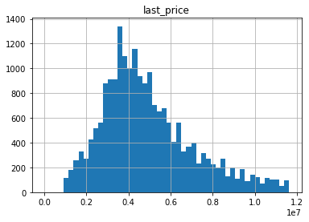

```python
df.hist(column='last_price',
        bins=50,
        range=(0,top_range('last_price'))
        )
```

Гистограмма цен близка к нормальному распределению, что говорит о доствоерности имеющихся данных. Наибольшее количество объявлений размещено для объектов стоимостью от 3 до 5 млн.руб.

**Площадь**

```python
square_to_analyse = ['total_area', 'living_area', 'kitchen_area']
```

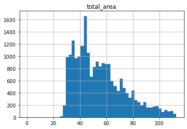

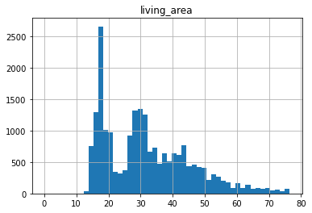

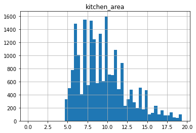

```python
for col in square_to_analyse:
    df.hist(column=col, bins=50, range=(0,top_range(col)))
```

Гистограммы общей площади и площади кухни также соответствуют нормальному распределению и свидетельствуют о корректности данных.

**Количество комнат**

```
array([[<AxesSubplot:title={'center':'rooms'}>]], dtype=object)
```

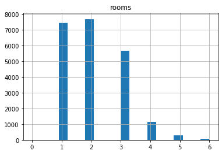

```python
df.hist(column='rooms', bins=20, range=(0,top_range('rooms')))
```

Наибольшее количество объявлений для однокомнатных и двухкомнатных квартир, что коррелирует с данными по площади и стоимости.

**Высота потолков**

```
array([[<AxesSubplot:title={'center':'ceiling_height'}>]], dtype=object)
```

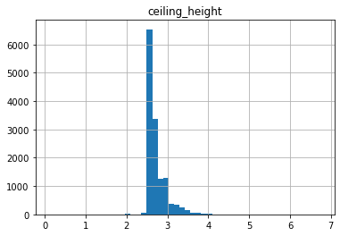

```python
df.hist(column='ceiling_height', bins=50, range=(0.1,top_range('ceiling_height')))
```

Также наблюдается кратность `5см` для высоты потолков.

**Этажность**

```python
floors_to_analyse = ['floor', 'floors_total']
```

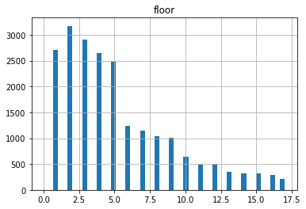

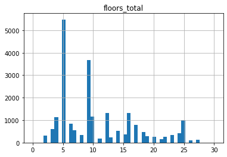

```python
for col in floors_to_analyse:
    df.hist(column=col, bins=50, range=(0,top_range(col)))
```

```
array([[<AxesSubplot:title={'center':'floor_type_id'}>]], dtype=object)
```

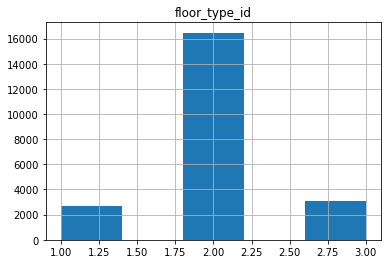

```python
df.hist(column='floor_type_id', bins=5)
```

Как видно из гистограммы `floors_total` - больше всего объявлений размещено для квартир в 5-ти и 9-ти этажных домах. Следовательно, чаще всего этаж, на котором расположена квартира находится в этом диапазоне. Гистограмма типа этажа также соответствует данному распределению

Также стоит заметить, что 1 этаж не является самым популярным, несмотря на то, что статистически таких квартир должно быть больше всего. Это может быть связано с тем, что в некоторых объявлениях может быть указан 2-й этаж, несмотря на то, что квартира фактически располагается на 1-м.

**Инфраструктура**

При построении гистограмм удаленности от инфраструктурных объектов исключаются заполненные на `0` пропуски.

```python
surrounding_to_analyse = ['cityCenters_nearest', 'airports_nearest', 'parks_nearest', 'ponds_nearest']
```

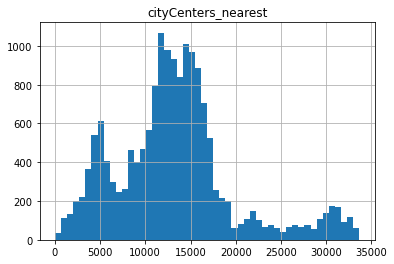

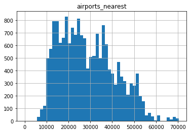

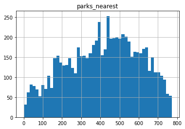

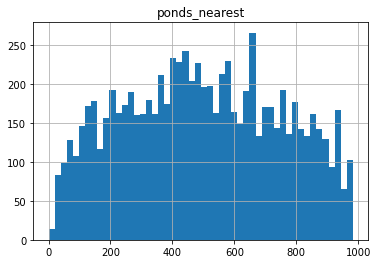

```python
for col in surrounding_to_analyse:
    df.hist(column=col, bins=50, range=(0.1,top_range(col)))

plt.show()
```

2 максимума значений удаленности от центра могут быть связаны с тем, что приведены данные для разных населенных пунктов. Следует проверить эту гипотезу, составив гистограмму только для недвижимости в Санкт-Петербурге.

```
array([[<AxesSubplot:title={'center':'cityCenters_nearest'}>]],
      dtype=object)
```

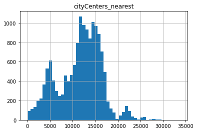

```python
df.query('locality_name == "Санкт-Петербург"').hist(column='cityCenters_nearest',
                                                    bins=50,
                                                    range=(0,top_range('cityCenters_nearest')))
```

Гипотеза оказалась ошибочной, 2 максимума наблюдаются в том числе для недвижимости Санкт-Петербурга.

**Размещение объявления**

```python
exposition_to_analyse = ['exposition_weekday', 'exposition_month', 'exposition_year']
```

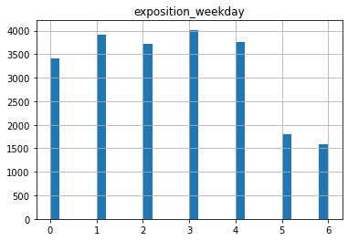

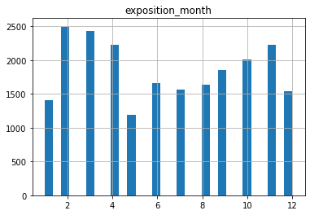

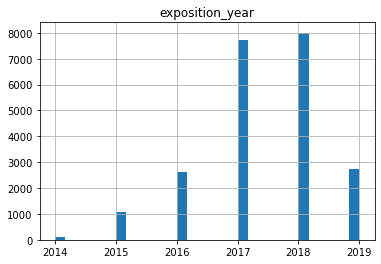

```python
for col in exposition_to_analyse:
    df.hist(column=col, bins=30)
```

Как видно, в выходные размещается наименьшее количество объявлений. Вероятно, это связано с графиком работы агенств недвижимости.

Также за последние 5 лет наблюдается значительный рост числа объявлений. Данные за 2019 год неполные, поэтому низкое значение данного столбца не является показателем снижения активности.

### Изучение скорости продажи недвижимости

```python
top_filter = df['days_exposition'].quantile(.9976)
df = df[df['days_exposition'] <= top_filter]

bottom_filter = df['days_exposition'].quantile(.01)
df = df[df['days_exposition'] >= bottom_filter]

df.info()
```

```
<class 'pandas.core.frame.DataFrame'>
Int64Index: 22196 entries, 0 to 23697
Data columns (total 29 columns):
 #   Column                  Non-Null Count  Dtype
---  ------                  --------------  -----
 0   total_images            22196 non-null  int64
 1   last_price              22196 non-null  float64
 2   total_area              22196 non-null  float64
 3   first_day_exposition    22196 non-null  datetime64[ns]
 4   rooms                   22196 non-null  int64
 5   ceiling_height          22196 non-null  float64
 6   floors_total            22196 non-null  int32
 7   living_area             22196 non-null  float64
 8   floor                   22196 non-null  int64
 9   is_apartment            22196 non-null  bool
```

[output cut: 21 more lines]

```python
df.query('days_exposition > 0')['days_exposition'].describe()
```

```
count    19212.000000
mean       174.651936
std        203.412633
min          1.000000
25%         45.000000
50%         95.000000
75%        227.000000
max       1163.000000
Name: days_exposition, dtype: float64
```

```python
exposition_less_than_7 = len(df.query('0 < days_exposition <=7')['days_exposition']) \
/ len(df.query('0 < days_exposition')['days_exposition'])

exposition_less_than_30 = len(df.query('0 < days_exposition <=30')['days_exposition']) \
/ len(df.query('0 < days_exposition')['days_exposition'])

exposition_less_than_90 = len(df.query('0 < days_exposition <=91')['days_exposition']) \
/ len(df.query('0 < days_exposition')['days_exposition'])

exposition_less_than_182 = len(df.query('0 < days_exposition <=182')['days_exposition']) \
/ len(df.query('0 < days_exposition')['days_exposition'])

exposition_less_than_365 = len(df.query('0 < days_exposition <=365')['days_exposition']) \
/ len(df.query('0 < days_exposition')['days_exposition'])

print(f'''Продается в течение недели: {exposition_less_than_7 :.1%} объектов;
Продается в течение месяца: {exposition_less_than_30 :.1%} объектов;
Продается в течение квартала: {exposition_less_than_90 :.1%} объектов;
Продается в течение полугода: {exposition_less_than_182 :.1%} объектов;
Продается в течение года: {exposition_less_than_365 :.1%} объектов.''')
```

```
Продается в течение недели: 4.2% объектов;
Продается в течение месяца: 18.3% объектов;
Продается в течение квартала: 48.9% объектов;
Продается в течение полугода: 69.2% объектов;
Продается в течение года: 85.7% объектов.
```

| Тип сделки | Срок размещения объявления | Доля проданных объектов |
| --- | --- | --- |
| Очень быстрая | 17 дней | 10% |
| Быстрая | 1.5 месяца | 25% |
| Нормальная | 3 месяца | 50% |
| Долгая | 7.5 месяцев | 75% |
| Очень долгая | 1.2 года | 90% |

### Зависимость цены от различных параметров

Необходимо оценить зависимость стоимости объектов недвижимости от следующих параметров:

- `общая площадь`
- `жилая площадь`
- `площадь кухни`
- `цена объекта`
- `количество комнат`
- `высота потолков`
- `этаж квартиры`
- `тип этажа квартиры` («первый», «последний», «другой»)
- `общее количество этажей в доме`
- `расстояние до центра города`
- `расстояние до ближайшего аэропорта`
- `расстояние до ближайшего парка`
- `день, месяц, год публикации объявления`

**Зависимость цены от площади**

```python
corr_area = ['total_area', 'living_area', 'kitchen_area']
```

[figure not shown]

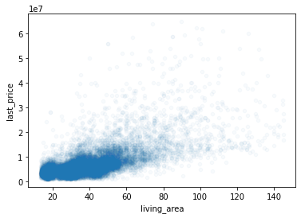

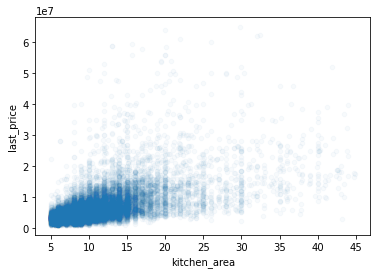

```python
for parameter in corr_area:

    df.plot(kind='scatter',
            x=parameter,
            y='last_price',
            alpha = 0.03
           )
```

Наблюдается положительная корреляция между площатью недвижимости и ее ценой.  
Причем для общей площади корреляция более явная.

**Зависимость цены от количества комнат**

Поскольку количество комнат является дискретным значением - вместо диаграммы рассеяния стоит построить график медиан.

```python
median_price_by_rooms = df.pivot_table(index='rooms', values='last_price', aggfunc='median')
median_price_by_rooms
```

[output not shown]

[figure not shown]

```python
median_price_by_rooms.plot(y='last_price',
                           kind='line',
                           style='o-');
```

**Зависимость цены от типа этажа**

Тип этажа также является дискретным значением, оцениваются медианные значения для каждой категории.

```python
median_price_by_foor_type = df.pivot_table(index='floor_type_id', values='last_price', aggfunc='median')
median_price_by_foor_type
```

| floor_type_id | last_price |
| --- | --- |
| 1 | 3999000.0 |
| 2 | 4900000.0 |
| 3 | 4350000.0 |

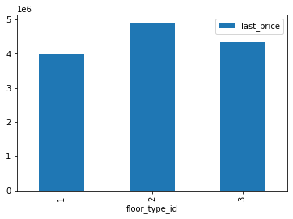

```python
median_price_by_foor_type.plot(y='last_price',
                               kind = 'bar'
                               );
```

**Зависимость цены от инфраструктуры**

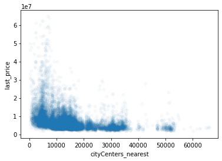

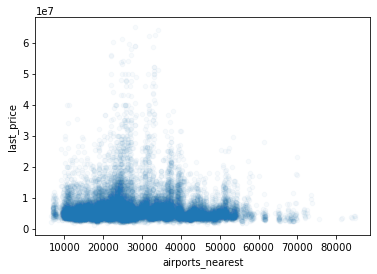

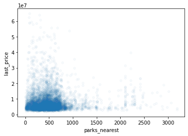

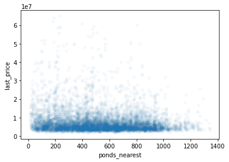

```python
infrastructure_list = ['cityCenters_nearest', 'airports_nearest', 'parks_nearest', 'ponds_nearest']

for parameter in infrastructure_list:
    df[df[parameter] > 0].plot(kind='scatter',
                               x=parameter,
                               y='last_price',
                               alpha = 0.03)
```

Наличие поблизости парков, а также удаленность от аэропорта практически не влияют на стоимость жилья, в отличие от удаленности от центра. Заметно падение стоимости жилья ближе к окраинам города.

**Зависимость цены от даты размещения объявления**

```python
corr_exposition = ['exposition_weekday', 'exposition_month', 'exposition_year']
```

| exposition_weekday | last_price |
| --- | --- |
| 0 | 4700000.0 |
| 1 | 4800000.0 |
| 2 | 4790000.0 |
| 3 | 4690000.0 |
| 4 | 4600000.0 |
| 5 | 4600000.0 |
| 6 | 4552500.0 |

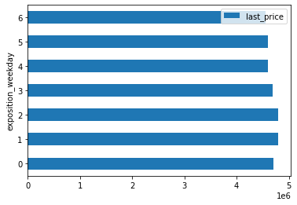

```python
median_price_by_exposition_weekday = df.pivot_table(index='exposition_weekday', values='last_price', aggfunc='median')

display(median_price_by_exposition_weekday)

median_price_by_exposition_weekday.plot(y='last_price',
                               kind = 'barh');
```

Зависимость цены от дня недели размещения объявления практически не проявляется

| exposition_month | last_price |
| --- | --- |
| 1 | 4700000.0 |
| 2 | 4700000.0 |
| 3 | 4700000.0 |
| 4 | 4800227.0 |
| 5 | 4590000.0 |
| 6 | 4499000.0 |
| 7 | 4700000.0 |
| 8 | 4600006.0 |
| 9 | 4750000.0 |
| 10 | 4600000.0 |
| 11 | 4700000.0 |
| 12 | 4700000.0 |

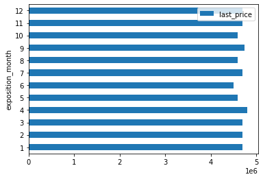

```python
median_price_by_exposition_month = df.pivot_table(index='exposition_month', values='last_price', aggfunc='median')

display(median_price_by_exposition_month)

median_price_by_exposition_month.plot(y='last_price',
                               kind = 'barh');
```

Наблюдается незначительное падение стоимости для объявлений, размещенных в мае и июне, однако размах диаграммы составляет менее 10%

| exposition_year | last_price |
| --- | --- |
| 2014 | 7388280.0 |
| 2015 | 5200000.0 |
| 2016 | 4600000.0 |
| 2017 | 4500000.0 |
| 2018 | 4650000.0 |
| 2019 | 5100000.0 |

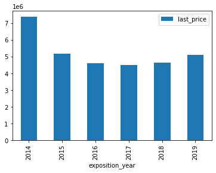

```python
median_price_by_exposition_year = df.pivot_table(index='exposition_year', values='last_price', aggfunc='median')

display(median_price_by_exposition_year)

median_price_by_exposition_year.plot(y='last_price',
                               kind = 'bar');
```

```python
median_price_by_exposition_year.describe()
```

[output not shown]

В период с 2014 по 2017 год наблюдалось падение цен на недвижимость, после чего средняя стоимость квартир начала расти.  
Стоит отметить, что высокое значение средней стоимости недвижимости в 2014 году может быть обусловлено нерелевантностью выборки (114 значений)